# 1 Books ratings data analysis

## 1.1 Background / context

Book rating is important or critical for books lovers, writers and readers. Very often for some of them,ratings provide the reader with some first insights about books and related features like author, publisher, category and guide the reader to buy, be tempt to or subject to buy it or not. In this application we have been instructed to predict any given new book ratings via a machine learning application mean. .

## 1.2 summary

This application is a supervised machine learning problem. Its could be tackled either as a regression or a classification problem. we would follow the following ML flow :  
1. Data testing  
1.1. data acquisition  
1.2. data inspection  
1.3. Data pre-processing or processing  
1.4. EDA : visualization  
1.5. features engineering  
2. Model testing. 2.1. Model testing  
2.2. model evaluation  
2.3. model validation  
3. Predictions  
4. recommendation

libraries

## 1.3 Data testing

### 1.3.1 data acquisition

load data

### 1.3.2 data inspection

data overview  
Table: Data summary

| Name | data |
| --- | --- |
| Number of rows | 11127 |
| Number of columns | 12 |
| _______________________ |  |
| Column type frequency: |  |
| character | 7 |
| numeric | 5 |
| ________________________ |  |
| Group variables | None |

deeper details

```
## [1] 0
```

There is no missing data in this dataset.

**Variable type: character**

| skim_variable | complete_rate | min | max | empty | n_unique | whitespace | length |
| --- | --- | --- | --- | --- | --- | --- | --- |
| title | 1 | 2 | 254 | 0 | 10352 | 0 | 11127 |
| authors | 1 | 3 | 750 | 0 | 6643 | 0 | 11127 |
| isbn | 1 | 9 | 10 | 0 | 11127 | 0 | 11127 |
| isbn13 | 1 | 13 | 13 | 0 | 11127 | 0 | 11127 |
| language_code | 1 | 2 | 5 | 0 | 27 | 0 | 11127 |
| publication_date | 1 | 8 | 10 | 0 | 3679 | 0 | 11127 |
| publisher | 1 | 2 | 67 | 0 | 2292 | 0 | 11127 |

Following this table, we can see that title has 10352 cases instead of 11127, which suggest that there are duplicates cases in title.

This table yields, 6643 authors, for 11127 books,which represents almost 2 books written by each authors roughly.

Publication_date has 3679 cases, this suggest that there are some point of time where a lot of book have been published.

**Variable type: numeric**

| skim_variable | complete_rate | mean | sd | median | iqr |
| --- | --- | --- | --- | --- | --- |
| bookID | 1 | 21310.94 | 13093.36 | 20287.00 | 21817.50 |
| average_rating | 1 | 3.93 | 0.35 | 3.96 | 0.36 |
| num_pages | 1 | 336.38 | 241.13 | 299.00 | 224.00 |
| ratings_count | 1 | 17936.41 | 112479.44 | 745.00 | 4889.50 |
| text_reviews_count | 1 | 541.85 | 2576.18 | 46.00 | 228.50 |

Data magnitude are very high and different each other.

Average_rating mean and median are close each to another other, this suggest that the variable distribution may be close to a normal one.

### 1.3.3 Data preprocessing or processing

clean publication date

## 1.4 EDA

### 1.4.1 1D EDA : investigate variable distribution

```
##    Min. 1st Qu.  Median    Mean 3rd Qu.    Max.
##   0.000   3.770   3.960   3.934   4.135   5.000
```

Hist average rating

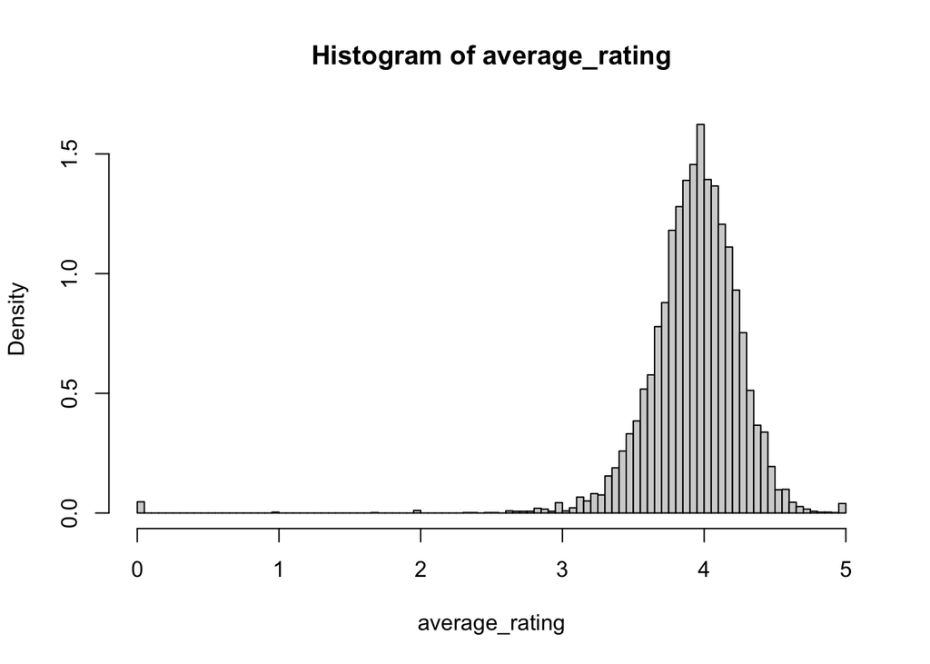

Density plot of average rating : interquartile range

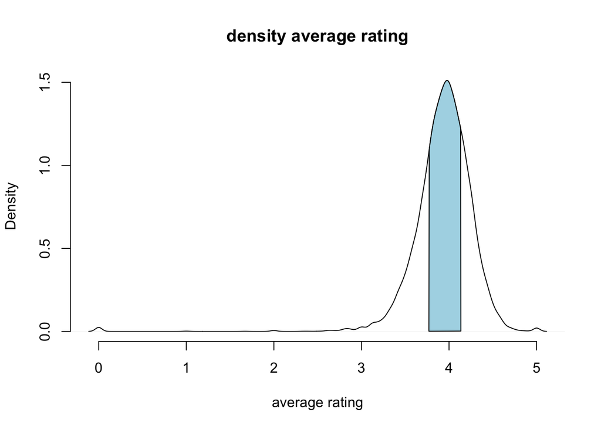

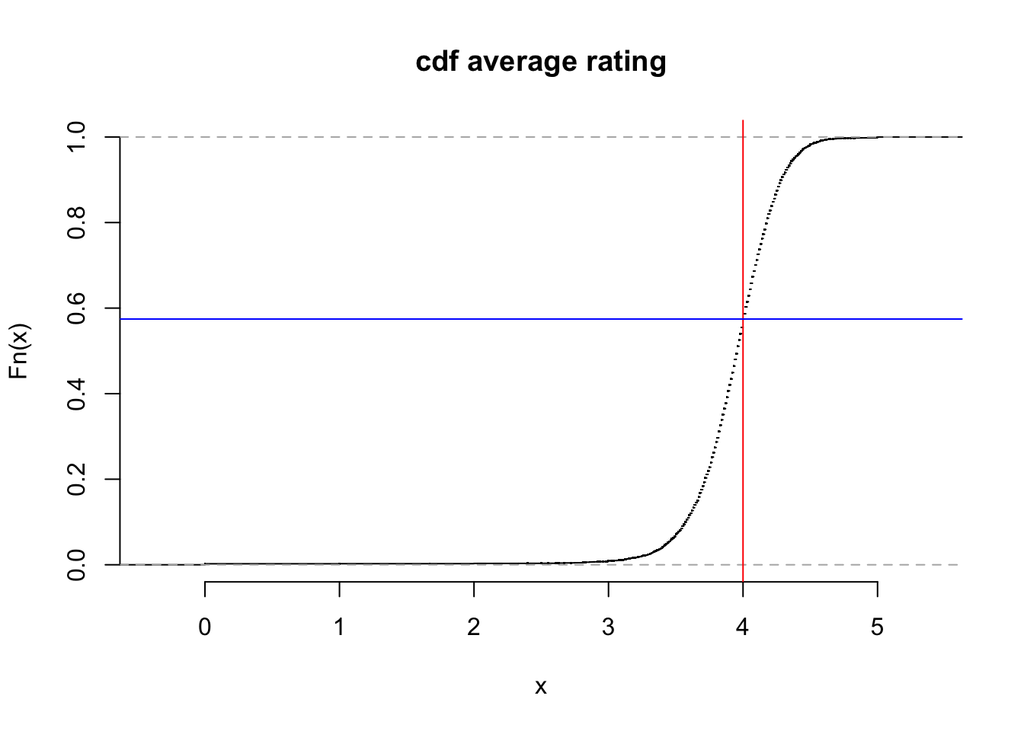

histogram of num pages

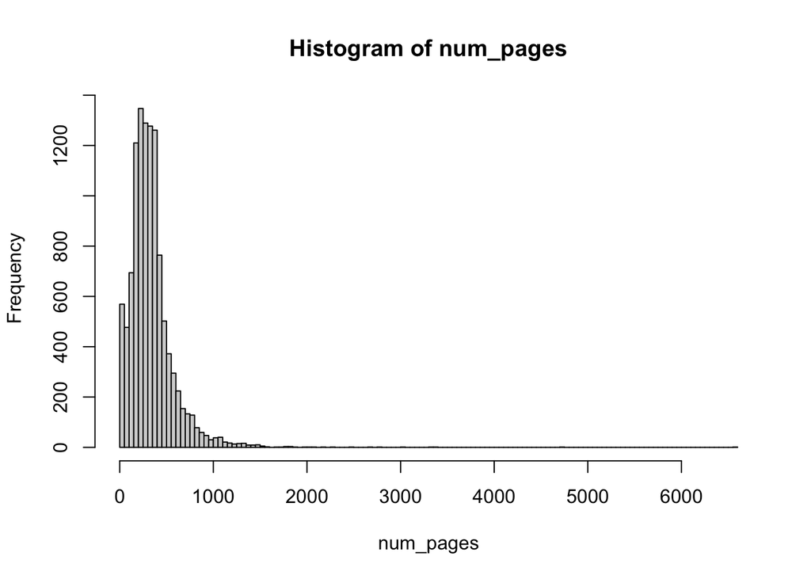

```
##    Min. 1st Qu.  Median    Mean 3rd Qu.    Max.
##     0.0   192.0   299.0   336.4   416.0  6576.0
```

histogram of text reviews count

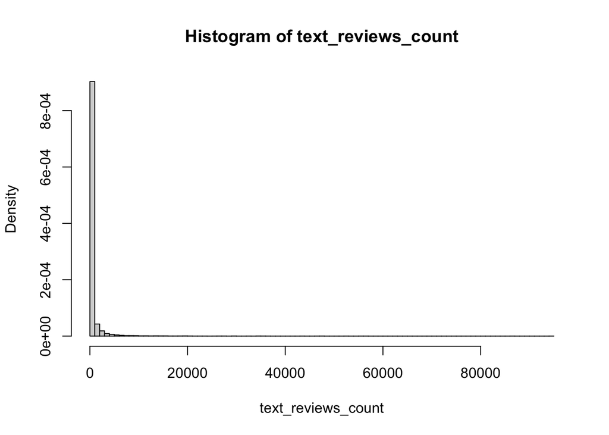

Text reviews count is right-skewed. There are many higher values in its distribution.

numerical summary text_reviews_count

```
##    Min. 1st Qu.  Median    Mean 3rd Qu.    Max.
##     0.0     9.0    46.0   541.9   237.5 94265.0
```

```
##
##  IQR text_reviews_count : 228.5
```

On average, 25 up to 75% text reviews counts are between 9 to 237.5.

```
## [1] "Twilight (Twilight  #1)"
```

Twilight book1 is the book with the book with the highest text_reviews_count

hist ratings counts

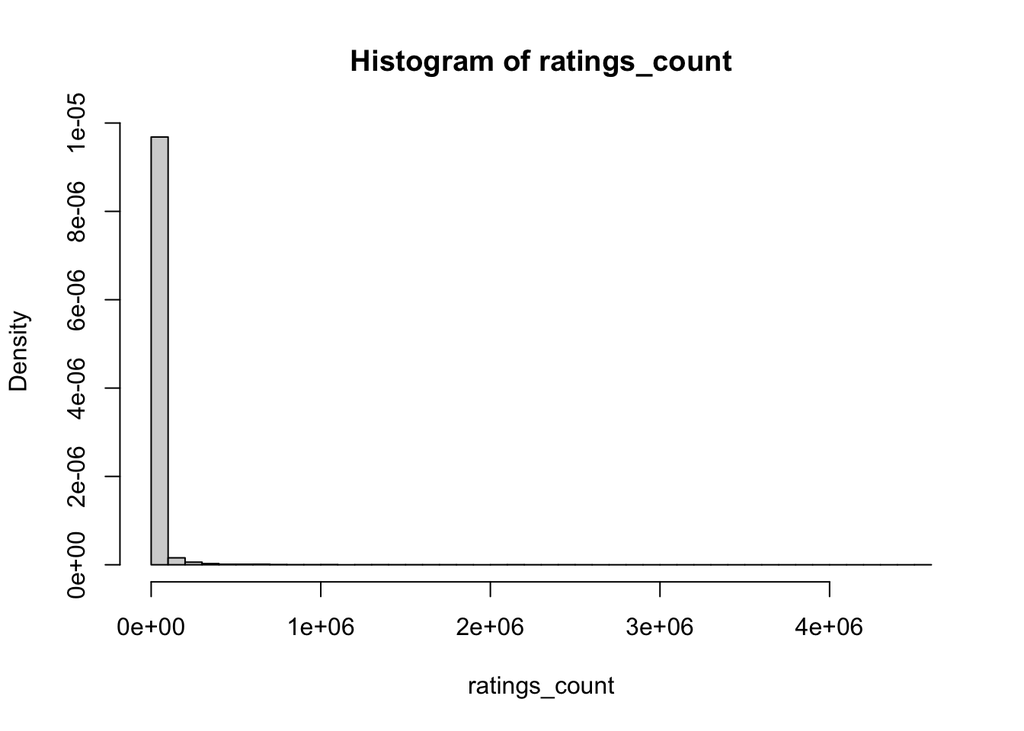

The distribution is right skewed, many high values are present is ratings count distribution.

summary ratings count

```
##    Min. 1st Qu.  Median    Mean 3rd Qu.    Max.
##       0     104     745   17936    4994 4597666
```

Which book has ratings_count of max rating count : a suspect count ?

```
## [1] "Twilight (Twilight  #1)"
```

Let’s discretize average rating in five (5) classes : bar plot

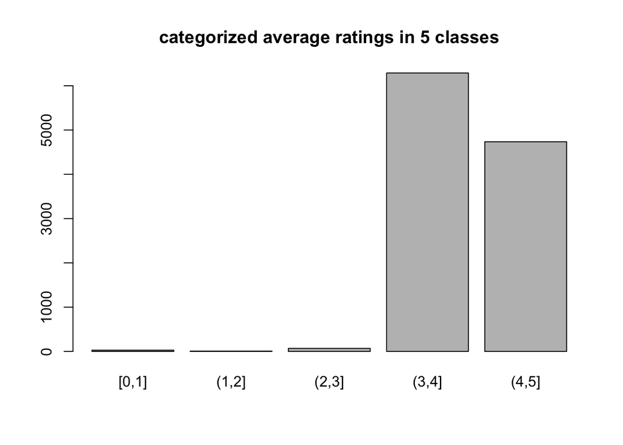

discrete average_rating yields also high frequencies in (3-4] and (4-5] classes.  
Discrete average rating ecdf

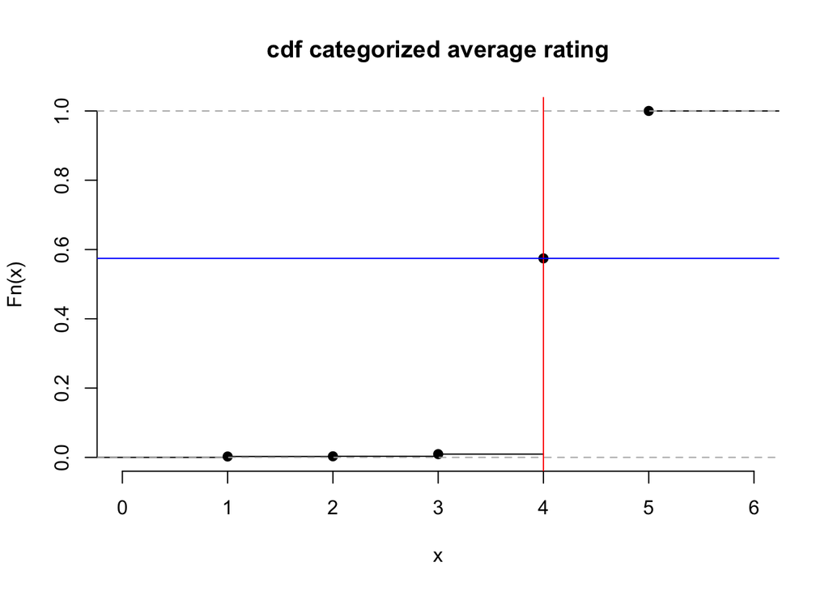

Discrete average rating frequencies table

Density table Discrete Average rating

```
##
## [0,1] (1,2] (2,3] (3,4] (4,5]
## 0.003 0.001 0.006 0.565 0.426
```

The proportion of books rated in class 3-4 is .56, while it is .42 for 4-5 class.

```
## [1] 0.991
```

On average, 99% of books are rated between 3 and 5

```
## [0,1] (1,2] (2,3] (3,4] (4,5]
##   0.0   0.0   0.0   0.6   1.0
```

```
##
##  proportion of average rating greater or equal to  4
```

```
## [1] 0.4
```

Here, 60% of books received an average rating less or equal to 4. Discretizing average rating in `5` classes turn it heavily unbalanced.

= analysis of categorical variable =

```
## # A tibble: 6 × 8
##   title                      authors isbn  isbn13 langu…¹ publi…² publi…³ av_cat
##   <chr>                      <chr>   <chr> <chr>  <chr>   <chr>   <chr>   <fct>
## 1 "Harry Potter and the Hal… J.K. R… 0439… 97804… eng     9-16-2… Schola… (4,5]
## 2 "Harry Potter and the Ord… J.K. R… 0439… 97804… eng     9-1-20… Schola… (4,5]
## 3 "Harry Potter and the Cha… J.K. R… 0439… 97804… eng     11-1-2… Schola… (4,5]
## 4 "Harry Potter and the Pri… J.K. R… 0439… 97804… eng     5-1-20… Schola… (4,5]
## 5 "Harry Potter Boxed Set  … J.K. R… 0439… 97804… eng     9-13-2… Schola… (4,5]
## 6 "Unauthorized Harry Potte… W. Fre… 0976… 97809… en-US   4-26-2… Nimble… (3,4]
## # … with abbreviated variable names ¹language_code, ²publication_date,
## #   ³publisher
```

qualitative data names.

```
## [1] "title"            "authors"          "isbn"             "isbn13"
## [5] "language_code"    "publication_date" "publisher"        "av_cat"
```

what are the 5 most high rated titles on average?

```
## # A tibble: 5 × 2
## # Groups:   title [5]
##   title                                                                  avera…¹
##   <chr>                                                                    <dbl>
## 1 Comoediae 1: Acharenses/Equites/Nubes/Vespae/Pax/Aves                        5
## 2 Willem de Kooning: Late Paintings                                            5
## 3 Literature Circle Guide: Bridge to Terabithia: Everything You Need Fo…       5
## 4 Middlesex Borough (Images of America: New Jersey)                            5
## 5 Zone of the Enders: The 2nd Runner Official Strategy Guide                   5
## # … with abbreviated variable name ¹average_rating
```

What are the five authors with high rated books ?

```
## # A tibble: 5 × 2
##   authors                                          mean_avg_rating
##   <chr>                                                      <dbl>
## 1 Aristophanes/F.W. Hall/W.M. Geldart                            5
## 2 Chris    Green/Chris Wright/Paul Douglas Gardner               5
## 3 Dennis Adler/R.L. Wilson                                       5
## 4 Elena N. Mahlow                                                5
## 5 Ian        Martin/Katie Elliott                                5
```

What are the 5 languages that occur the most ?

```
## # A tibble: 5 × 3
##   language_code num_books_published   prop
##   <chr>                       <int>  <dbl>
## 1 eng                          8911 0.801
## 2 en-US                        1409 0.127
## 3 spa                           218 0.0196
## 4 en-GB                         214 0.0192
## 5 fre                           144 0.0129
```

```
## [1] 0.95
```

bin language code

```
## proportion of binary language code :
```

```
##
##    0    1
## 0.05 0.95
```

What are the 5 publishers with most high rated books ?

```
## # A tibble: 5 × 2
##   publisher           mean_avg_rating
##   <chr>                         <dbl>
## 1 Academica Press                   5
## 2 Boosey & Hawkes Inc               5
## 3 Chartwell Books                   5
## 4 Courage Books                     5
## 5 Raintree                          5
```

Which year displays the highest number of book published ? Let’s check date format

which year display high rating frequencies ?

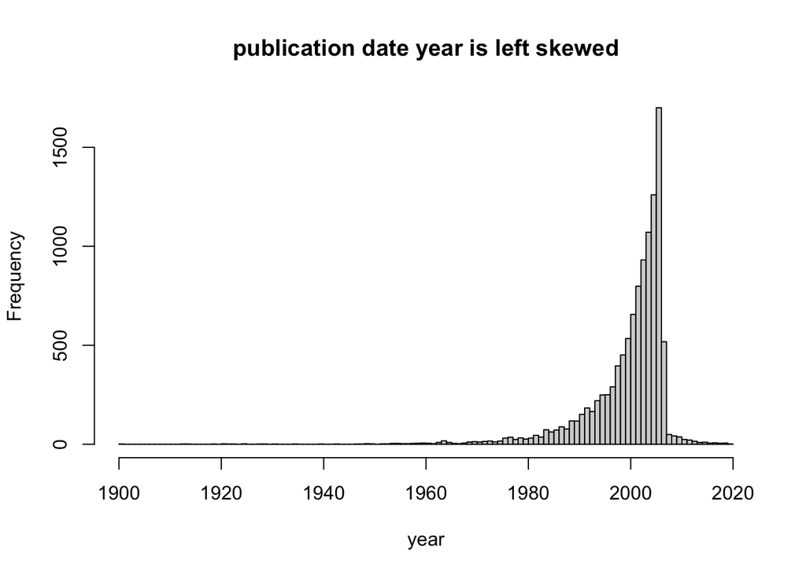

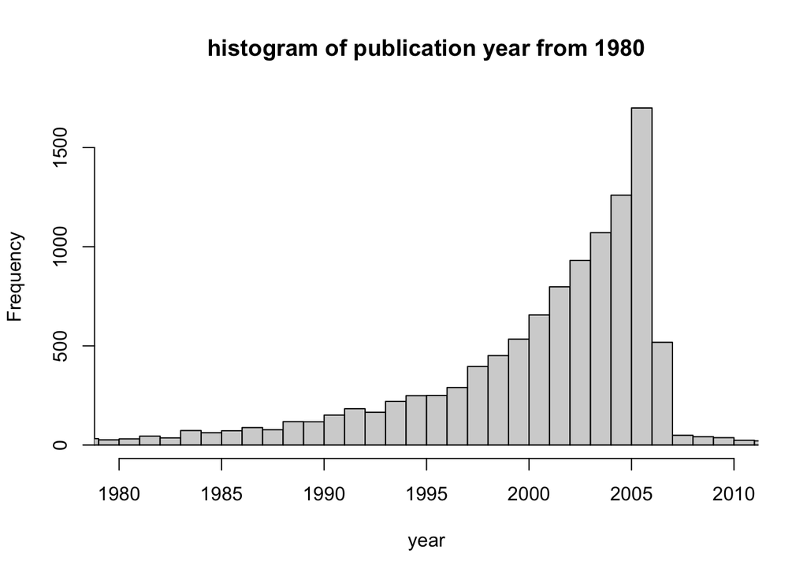

numerical summary of year : What is the year with the highest frequency of publication?

```
## # A tibble: 1 × 2
##    year counts
##   <dbl>  <int>
## 1  2006   1700
```

### 1.4.2 1D EDA summary

Books have been published from 1900 to 2020. Year 2006 yields the highest frequency of published books i.e. 1700.

### 1.4.3 2D EDA

== Correlation === which numerical variables are correlated ?

```
##                         bookID average_rating   num_pages ratings_count
## bookID              1.00000000    -0.03694922 -0.02622340   -0.07681474
## average_rating     -0.03694922     1.00000000  0.15080946    0.03820510
## num_pages          -0.02622340     0.15080946  1.00000000    0.03435344
## ratings_count      -0.07681474     0.03820510  0.03435344    1.00000000
## text_reviews_count -0.08128387     0.03373432  0.03699839    0.86597866
## year                0.02716418    -0.02879931 -0.01920035    0.04457594
##                    text_reviews_count        year
## bookID                    -0.08128387  0.02716418
## average_rating             0.03373432 -0.02879931
## num_pages                  0.03699839 -0.01920035
## ratings_count              0.86597866  0.04457594
## text_reviews_count         1.00000000  0.06692272
## year                       0.06692272  1.00000000
```

```
##                    bookID average_rating num_pages ratings_count
## bookID                  0              0         0             0
## average_rating          0              0         1             0
## num_pages               0              1         0             0
## ratings_count           0              0         0             0
## text_reviews_count      0              0         0             1
## year                    0              0         0             0
##                    text_reviews_count year
## bookID                              0    0
## average_rating                      0    0
## num_pages                           0    0
## ratings_count                       1    0
## text_reviews_count                  0    0
## year                                0    0
```

What is the number of book published by year and their associated average rating

```
## # A tibble: 5 × 3
##    year num_books_published avg_rating
##   <dbl>               <int>      <dbl>
## 1  2006                1700       3.91
## 2  2005                1260       3.93
## 3  2004                1071       3.95
## 4  2003                 931       3.93
## 5  2002                 798       3.94
```

how is average rating distributed across the years ?

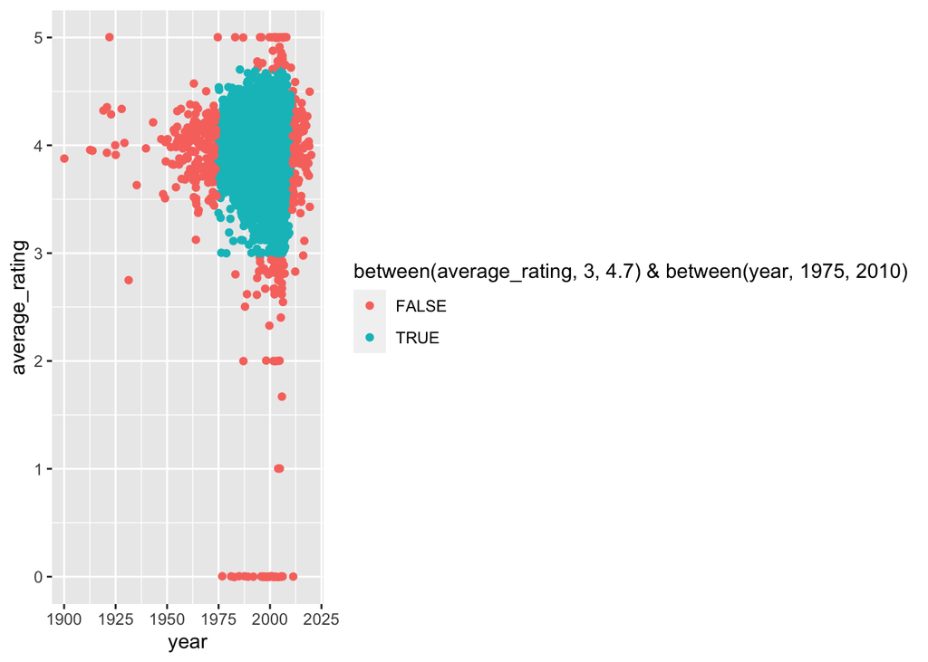

```
## $colour
## [1] "average rating between 3 and 4.7 and\n       year between 1975 and 2006"
##
## $title
## [1] "average rating between 3 and 4.7 for years range 1900 to 2020"
##
## attr(,"class")
## [1] "labels"
```

high rated books ,had been published between 1975 and 2006.

In which years do average ratings in the range of 2.7 and 4.5 fall?

In which range did average rating fall between 1990 and 2020?

Most books are rated between 2.75 and 4.7.

Across years , most books are rated between 2.7 and 4.5. The distribution of average ratings in any year range is almost similar.

what are the top 5 ratings counts with highest mean average rating across years ?

```
## # A tibble: 5 × 3
##    year average_rating_mean ratings_count_mean
##   <dbl>               <dbl>              <dbl>
## 1  1922                5                     0
## 2  1928                4.34                110
## 3  1919                4.32                208
## 4  1923                4.29                 35
## 5  1943                4.21                 70
```

```
## [1] 0.04
```

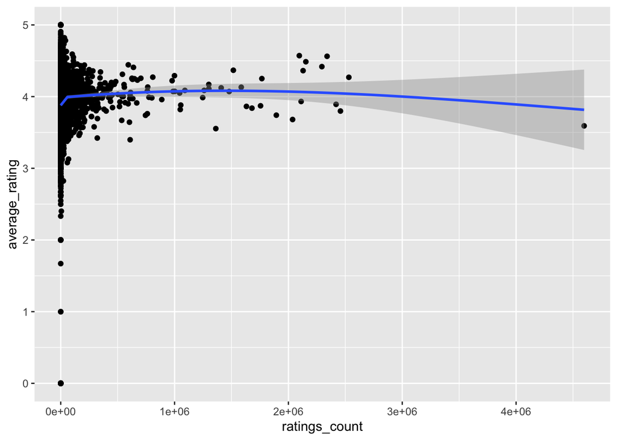

There is not a clear linear pattern between rating counts and average rating.

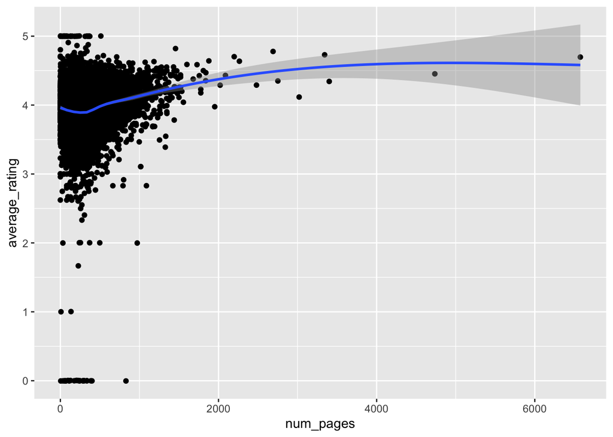

There is a weak linear pattern between average rating and num_pages and a slightly non-linear pattern.

```
## [1] 0.15
```

The correlation coefficient between average rating and num_pages is 0.15. This suggest a very weak linear relationship between average rating and num_pages.

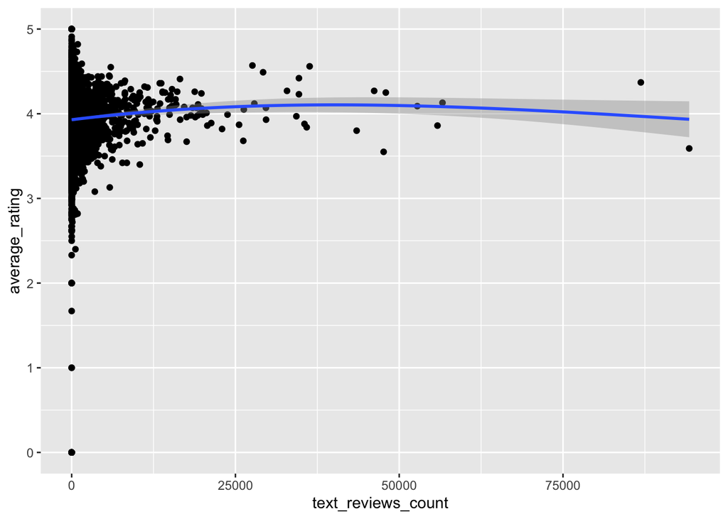

```
## [1] 0.03
```

The correlation coefficient between average rating and text_count_reviews is 0.03 suggesting a very weak linear relationship near to not existing between average rating and text reviews count.

## 1.5 2D section summary :

No numerical variable has correlation coefficient above 0.5 with average rating, though, considering a linear relationship, none of them has enough predictive power over average_ratings.

We notice a high positive correlation (0.87), between rating_counts and text_reviews_count. This suggest that they are correlated hence introducing redundancy or convey the same information pattern. We would advise to remove one of it.

Considering this results we suggest to investigate underlying non-linear relationships between average rating and remaining features.

## 1.6 features engineering

We will be looking for variables having effective predictive power over average rating in a linear regression setting. Then remove it in case of linear model setting in model testing.

Let’s split data and test default models.  
split data

= hypothesis testing for linear relation between target and numerical variable =

we test the relationship between average rating and numerical variables.  
H0 : there is no relationship between average_rating and numerical variables  
H1 : there is a relationship between average_ratings and numerical variables.

lm

```r
# use list of methods
 lm <- train(average_rating~. - av_cat,
       method = "lm",
       data = train1
       )
```

linear model summary table

```
## # A tibble: 3 × 5
##   term            estimate std.error statistic  p.value
##   <chr>              <dbl>     <dbl>     <dbl>    <dbl>
## 1 (Intercept)     3.90     0.0189       206.   0
## 2 language_code1 -0.0411   0.0185        -2.22 2.65e- 2
## 3 num_pages       0.000218 0.0000176     12.4  5.35e-35
```

remove text_reviews_count

-We will remove some categorical features without variation i.e. isbn, isbn13, bookID, authors, title or that with very low variation or those without any relation with average ratings following the lm model. Also remove following qualitative variables,

Let’s split data and test some non-linear models.

## 1.7 model testing

- Test some models and make a choice to finalize our study on regression sub-section.
- test categorical average rating against models and make a model choice if it is the case.

== regression ==  
rf regression lm

lasso

ridge

gbm

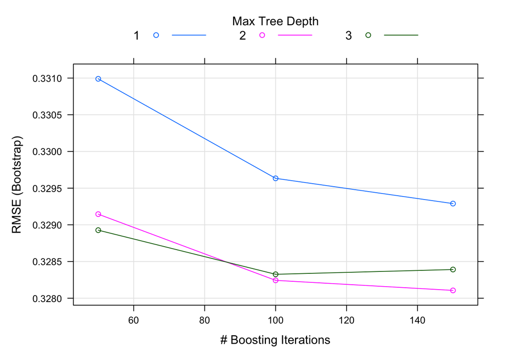

xgboost model

xgboost rmse model

```
## xgboost model performance on valid set :
```

```
## $train_rmse
## [1] 0.008537608
##
## $eval_rmse
## [1] 0.008951449
```

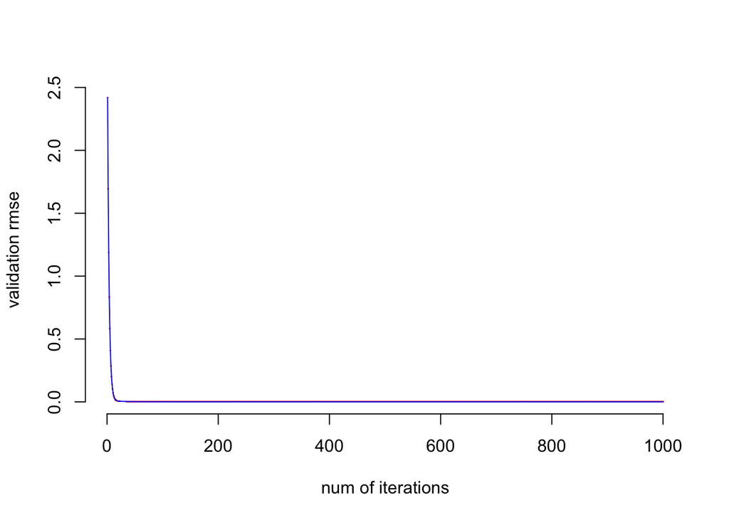

This model tends to overfit. to be check…

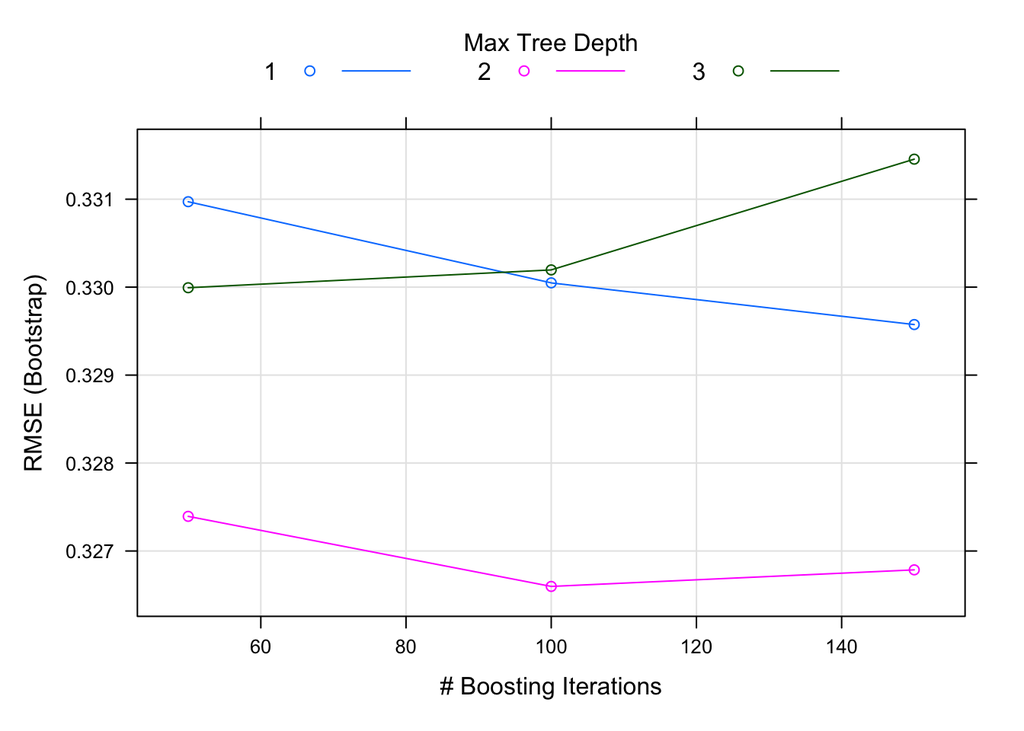

svm

[figure not shown]

```
## numeric(0)
```

```
##      gbm.MAE svmLinear.MAE bstTree.MAE
## [1,] 0.2284  0.2332        0.2272
```

```
##      gbm.RMSE svmLinear.RMSE bstTree.RMSE
## [1,] 0.328    0.36           0.326
```

== Regression conclusion === Following this model testing, I would advise bstTree (boosting tree) or xgboost (extreme gradient boosting machine ) models for a regression application for now.

== classification ==  
considering average rating as categorical variable turn our application into a multi-class classification problem. We want to see if a classification application is a better choice for our application.

I will test algorithm and make a choice.

```
##
## [0,1] (1,2] (2,3] (3,4] (4,5]
##    20     1    44  4018  3039
```

== sampling data ==

rf classification

```r
rf_class <- train(av_cat~. -average_rating,
            method = "ranger",
            trControl= trainControl(allowParallel = TRUE),
            data = train1)
```

### 1.7.1 Conclusion

This is to be continued with model evaluation.  
### model evaluation  
### model selection / validation. ## recommendation if necessary